# Trabajo 01 (Individual): Teoría de la Decisión bajo Incertidumbre

Documento 2 de 2 — Enunciados y soluciones

Autor/a

Esteban Blanco Díaz

Fecha de publicación

21/10/2026

Este documento contiene los **enunciados** de los dos problemas de Teoría de la Decisión bajo Incertidumbre y, a continuación, su **resolución paso a paso** con la ayuda del código R utilizado en la asignatura.

El documento 1 de 2, que contiene **solo los enunciados**, es *Trabajo 01 (individual): Enunciados de los problemas*.

# 1 Preparación: instalación y carga del código R

Todas las funciones de decisión bajo incertidumbre de la asignatura están disponibles en el **paquete R `TDecisionCodigo`**, que está en GitHub. Se instala una sola vez con `remotes`:

```r
#install.packages("remotes")
remotes::install_github("calote/TDecisionCodigo")
```

Una vez instalado, basta con cargarlo con `library()` para tener disponibles **todas** las funciones de la asignatura:

```r
library(TDecisionCodigo)
```

## 1.1 Guía rápida de las funciones que se van a usar

| Función R | Criterio | Qué devuelve |
| --- | --- | --- |
| `crea.tablaX(v, numalternativas, numestados, nb_alternativas, nb_estados)` | — | Construye la matriz de decisión a partir de un vector escrito **por filas** |
| `criterio.Wald(tablaX, favorable)` | Wald o pesimista | `ValorAlternativas` (peor caso de cada alternativa) y `AlternativaOptima` |
| `criterio.Optimista(tablaX, favorable)` | Optimista | `ValorAlternativas` (mejor caso de cada alternativa) y `AlternativaOptima` |
| `criterio.Hurwicz(tablaX, alfa, favorable)` | Hurwicz | `ValorAlternativas` (valor de Hurwicz de cada alternativa) y `AlternativaOptima` |
| `criterio.Savage(tablaX, favorable)` | Savage (regret) | `ValorAlternativas` (máximo regret de cada alternativa) y `AlternativaOptima` |
| `criterio.Laplace(tablaX, favorable)` | Laplace (equiprobabilidad) | `ValorAlternativas` (media de cada alternativa) y `AlternativaOptima` |
| `criterio.PuntoIdeal(tablaX, favorable)` | Punto ideal (distancia euclídea) | `ValorAlternativas` (distancia de cada alternativa al punto ideal) y `AlternativaOptima` |
| `criterio.Todos(tablaX, alfa, favorable)` | Todos a la vez | **Una sola tabla** con la decisión, el valor de cada criterio y la alternativa óptima de cada criterio |
| `dibuja.criterio.Hurwicz_Intervalos(tablaX, favorable)` | Hurwicz | `$IntervalosAlfa` (tramos de $\alpha$ y alternativa óptima) y `$PuntosDeCorte` |

> **Nota sobre el argumento `favorable`.** Cuando `favorable = TRUE` la tabla contiene **beneficios** y se **maximiza** el valor de cada criterio. Cuando `favorable = FALSE` la tabla contiene **costes** y se **minimiza**.

# 2 Problema 1: decisión de una delegación (datos inventados)

## 2.1 Enunciado

La dirección de *Estudio Otto S.L.*, una empresa de arquitectura*, debe decidir **en qué ciudad abrir su nueva delegación**. Las cuatro ciudades candidatas son las alternativas $d_1, d_2, d_3$ y $d_4$.

Los tres **estados de la naturaleza** representan los escenarios de demanda que pueden darse durante el primer año de actividad de la delegación:

- $e_1$: demanda **alta**;
- $e_2$: demanda **media**;
- $e_3$: demanda **baja**.

### 2.1.1 Apartado (a): situación favorable (beneficios)

Beneficio neto (ingresos menos gastos de explotación) esperado para el primer año, en **miles de euros**:

| Alternativa | $e_1$ (demanda alta) | $e_2$ (demanda media) | $e_3$ (demanda baja) |
| --- | --- | --- | --- |
| $d_1$ | 125 | 95 | 70 |
| $d_2$ | 100 | 115 | 50 |
| $d_3$ | 85 | 85 | 85 |
| $d_4$ | 145 | 60 | 40 |

Se pide aplicar **cada uno de los seis criterios, de forma individual**, en **situación favorable**, justificar la alternativa óptima de cada uno, ver qué alternativa resulta óptima con más criterios y estudiar el criterio de Hurwicz en todo el rango $\alpha \in (0,1)$.

### 2.1.2 Apartado (b): situación desfavorable (costes)

Coste total de apertura (inversión inicial más puesta en marcha) de la delegación en cada ciudad, también en **miles de euros**:

| Alternativa | $e_1$ (demanda alta) | $e_2$ (demanda media) | $e_3$ (demanda baja) |
| --- | --- | --- | --- |
| $d_1$ | 250 | 300 | 340 |
| $d_2$ | 220 | 280 | 400 |
| $d_3$ | 300 | 260 | 310 |
| $d_4$ | 400 | 230 | 290 |

Se pide aplicar **cada uno de los seis criterios, de forma individual**, en **situación desfavorable**, justificar la alternativa óptima de cada uno, ver qué alternativa resulta óptima con más criterios y estudiar el criterio de Hurwicz en todo el rango $\alpha \in (0,1)$.

## 2.2 Preparación de los datos en R

Se construyen las dos matrices de decisión. Los datos se introducen **por filas**, es decir, la primera fila del vector corresponde a $d_1$, la segunda a $d_2$, etc.

```r
## Apartado (a): situación favorable (beneficios)
dat1a <- crea.tablaX(c(125, 95, 70,
                      100, 115, 50,
                      85, 85, 85,
                      145, 60, 40),
                    numalternativas = 4,
                    numestados = 3,
                    nb_alternativas = c("d1", "d2", "d3", "d4"),
                    nb_estados = c("e1 alta", "e2 media", "e3 baja"))

## Apartado (b): situación desfavorable (costes)
dat1b <- crea.tablaX(c(250, 300, 340,
                      220, 280, 400,
                      300, 260, 310,
                      400, 230, 290),
                    numalternativas = 4,
                    numestados = 3,
                    nb_alternativas = c("d1", "d2", "d3", "d4"),
                    nb_estados = c("e1 alta", "e2 media", "e3 baja"))

dat1a
```

```
   e1 alta e2 media e3 baja
d1     125       95      70
d2     100      115      50
d3      85       85      85
d4     145       60      40
```

```r
dat1b
```

```
   e1 alta e2 media e3 baja
d1     250      300     340
d2     220      280     400
d3     300      260     310
d4     400      230     290
```

## 2.3 Apartado (a): situación favorable

### 2.3.1 1. Criterio de Wald (maximin)

**Idea.** Es el criterio del pesimista. Para cada alternativa se calcula su **peor caso** (mínimo de la fila) y se elige la alternativa cuyo peor caso es **el mejor de todos**.

$$W_i = \min_j\, x_{ij}, \qquad d^* = \arg\max_i W_i$$

**Cálculo manual.** Peor caso de cada alternativa:

- $d_1$: $\min(125, 95, 70) = 70$
- $d_2$: $\min(100, 115, 50) = 50$
- $d_3$: $\min(85, 85, 85) = 85$
- $d_4$: $\min(145, 60, 40) = 40$

El mayor de los cuatro peores casos es $85$, luego **la alternativa óptima es $d_3$**: es la única que garantiza al menos 85 mil euros incluso en el peor escenario.

```r
res <- criterio.Wald(dat1a, favorable = TRUE)
res$ValorAlternativas
```

```
d1 d2 d3 d4
70 50 85 40
```

```r
res$AlternativaOptima
```

```
d3
 3
```

```r
res$ValorOptimo
```

```
[1] 85
```

### 2.3.2 2. Criterio Optimista (maximax)

**Idea.** Es el criterio del optimista. Se toma el **mejor caso** (máximo de la fila) de cada alternativa y se elige la alternativa con el mejor de esos mejores casos.

$$M_i = \max_j\, x_{ij}, \qquad d^* = \arg\max_i M_i$$

**Cálculo manual.** Mejor caso de cada alternativa:

- $d_1$: $\max(125, 95, 70) = 125$
- $d_2$: $\max(100, 115, 50) = 115$
- $d_3$: $\max(85, 85, 85) = 85$
- $d_4$: $\max(145, 60, 40) = 145$

El mayor es $145$, luego **la alternativa óptima es $d_4$**.

```r
res <- criterio.Optimista(dat1a, favorable = TRUE)
res$ValorAlternativas
```

```
 d1  d2  d3  d4
125 115  85 145
```

```r
res$AlternativaOptima
```

```
d4
 4
```

```r
res$ValorOptimo
```

```
[1] 145
```

### 2.3.3 3. Criterio de Hurwicz ($\alpha = 0{,}3$)

**Idea.** Es un criterio intermedio: combina el mejor y el peor caso con un factor de optimismo $\alpha \in (0,1)$. Con $\alpha = 0$ se reduce al criterio de Wald y con $\alpha = 1$ al optimista.

$$H_i(\alpha) = \alpha \cdot M_i + (1-\alpha)\cdot W_i, \qquad d^* = \arg\max_i H_i(\alpha)$$

**Cálculo manual** con $\alpha = 0{,}3$ (y $1-\alpha = 0{,}7$):

- $d_1$: $0{,}3 \cdot 125 + 0{,}7 \cdot 70 = 37{,}5 + 49 = 86{,}5$
- $d_2$: $0{,}3 \cdot 115 + 0{,}7 \cdot 50 = 34{,}5 + 35 = 69{,}5$
- $d_3$: $0{,}3 \cdot 85 + 0{,}7 \cdot 85 = 85$
- $d_4$: $0{,}3 \cdot 145 + 0{,}7 \cdot 40 = 43{,}5 + 28 = 71{,}5$

El mayor valor es $86{,}5$, luego **la alternativa óptima es $d_1$**.

```r
res <- criterio.Hurwicz(dat1a, alfa = 0.3, favorable = TRUE)
res$ValorAlternativas
```

```
  d1   d2   d3   d4
86.5 69.5 85.0 71.5
```

```r
res$AlternativaOptima
```

```
d1
 1
```

```r
res$ValorOptimo
```

```
[1] 86.5
```

### 2.3.4 4. Criterio de Savage (minimax del regret)

**Idea.** Se construye la matriz de **regret** (o *arrepentimiento*) $r_{ij} = \max_i x_{ij} - x_{ij}$: cuánto se pierde, en cada estado, con respecto a la mejor alternativa posible en ese estado. Después se aplica Wald (minimax) a esa matriz de regret.

**Cálculo manual.** Mejor valor en cada estado (por columna):

- $e_1$: $\max(125, 100, 85, 145) = 145$ (lo consigue $d_4$)
- $e_2$: $\max(95, 115, 85, 60) = 115$ (lo consigue $d_2$)
- $e_3$: $\max(70, 50, 85, 40) = 85$ (lo consigue $d_3$)

Matriz de regret $r_{ij}$:

|  | $e_1$ | $e_2$ | $e_3$ | Máx. regret |
| --- | --- | --- | --- | --- |
| $d_1$ | $145-125=20$ | $115-95=20$ | $85-70=15$ | **20** |
| $d_2$ | $145-100=45$ | $115-115=0$ | $85-50=35$ | **45** |
| $d_3$ | $145-85=60$ | $115-85=30$ | $85-85=0$ | **60** |
| $d_4$ | $145-145=0$ | $115-60=55$ | $85-40=45$ | **55** |

El menor de los máximos de regret es $20$, luego **la alternativa óptima es $d_1$**.

```r
res <- criterio.Savage(dat1a, favorable = TRUE)
res$Mejores        # mejor valor de cada estado (por columna)
```

```
 e1 alta e2 media  e3 baja
     145      115       85
```

```r
res$Pesos          # matriz de regret
```

```
   e1 alta e2 media e3 baja
d1      20       20      15
d2      45        0      35
d3      60       30       0
d4       0       55      45
```

```r
res$ValorAlternativas
```

```
d1 d2 d3 d4
20 45 60 55
```

```r
res$AlternativaOptima
```

```
d1
 1
```

```r
res$ValorOptimo
```

```
[1] 20
```

### 2.3.5 5. Criterio de Laplace (equiprobabilidad)

**Idea.** Se supone que los estados son equiprobables, de modo que el valor de cada alternativa es su **media aritmética**; se elige la mayor (o la menor, en costes).

$$L_i = \frac{1}{m}\sum_{j=1}^{m} x_{ij}, \qquad d^* = \arg\max_i L_i$$

**Cálculo manual.** Media de cada alternativa:

- $d_1$: $(125 + 95 + 70)/3 = 290/3 \approx 96{,}67$
- $d_2$: $(100 + 115 + 50)/3 = 265/3 \approx 88{,}33$
- $d_3$: $(85 + 85 + 85)/3 = 85$
- $d_4$: $(145 + 60 + 40)/3 = 245/3 \approx 81{,}67$

La mayor media es $96{,}67$, luego **la alternativa óptima es $d_1$**.

```r
res <- criterio.Laplace(dat1a, favorable = TRUE)
res$ValorAlternativas
```

```
      d1       d2       d3       d4
96.66667 88.33333 85.00000 81.66667
```

```r
res$AlternativaOptima
```

```
d1
 1
```

```r
res$ValorOptimo
```

```
[1] 96.66667
```

### 2.3.6 6. Criterio del Punto Ideal

**Idea.** Se construye el **punto ideal** (el mejor resultado posible en cada estado) y se elige la alternativa cuya **distancia euclídea** a ese punto es menor.

$$x^* = (\max_j x_{1j},\ldots,\max_j x_{mj}), \qquad
d_i = \sqrt{\sum_{j=1}^{m} (x_{ij} - x^*_j)^2}, \qquad d^* = \arg\min_i d_i$$

**Cálculo manual.** Punto ideal: $x^* = (145, 115, 85)$. Distancias:

- $d_1$: $\sqrt{(125-145)^2 + (95-115)^2 + (70-85)^2} = \sqrt{400+400+225} = \sqrt{1025} \approx 32{,}02$
- $d_2$: $\sqrt{(100-145)^2 + 0^2 + (50-85)^2} = \sqrt{2025+1225} = \sqrt{3250} \approx 57{,}01$
- $d_3$: $\sqrt{(85-145)^2 + (85-115)^2 + 0^2} = \sqrt{3600+900} = \sqrt{4500} \approx 67{,}08$
- $d_4$: $\sqrt{0^2 + (60-115)^2 + (40-85)^2} = \sqrt{3025+2025} = \sqrt{5050} \approx 71{,}06$

La menor distancia es $32{,}02$, luego **la alternativa óptima es $d_1$**.

```r
res <- criterio.PuntoIdeal(dat1a, favorable = TRUE)
res$Mejores        # punto ideal
```

```
 e1 alta e2 media  e3 baja
     145      115       85
```

```r
res$ValorAlternativas
```

```
      d1       d2       d3       d4
32.01562 57.00877 67.08204 71.06335
```

```r
res$AlternativaOptima
```

```
d1
 1
```

```r
res$ValorOptimo
```

```
[1] 32.01562
```

### 2.3.7 7. Votación de los criterios (apartado a)

```r
cri <- list(Wald      = criterio.Wald(dat1a, TRUE)$AlternativaOptima,
            Optimista = criterio.Optimista(dat1a, TRUE)$AlternativaOptima,
            Hurwicz   = criterio.Hurwicz(dat1a, 0.3, TRUE)$AlternativaOptima,
            Savage    = criterio.Savage(dat1a, TRUE)$AlternativaOptima,
            Laplace   = criterio.Laplace(dat1a, TRUE)$AlternativaOptima,
            PuntoIdeal= criterio.PuntoIdeal(dat1a, TRUE)$AlternativaOptima)
data.frame(Criterio = names(cri), Alternativa = as.character(cri))
```

| Criterio | Alternativa |
| --- | --- |
| Wald | c(d3 = 3) |
| Optimista | c(d4 = 4) |
| Hurwicz | c(d1 = 1) |
| Savage | c(d1 = 1) |
| Laplace | c(d1 = 1) |
| PuntoIdeal | c(d1 = 1) |

| Criterio | Alternativa óptima |
| --- | --- |
| Wald | $d_3$ |
| Optimista | $d_4$ |
| Hurwicz ($\alpha=0{,}3$) | $d_1$ |
| Savage | $d_1$ |
| Laplace | $d_1$ |
| Punto Ideal | $d_1$ |

### 2.3.8 8. Hurwicz en todo el rango $\alpha \in (0,1)$

**Idea.** El valor de Hurwicz de cada alternativa es una **función lineal de $\alpha$**:

$$H_i(\alpha) = \alpha\,M_i + (1-\alpha)\,W_i = W_i + \alpha\,(M_i - W_i)$$

Es decir, cada alternativa es una recta que pasa por $(0, W_i)$ y $(1, M_i)$. La alternativa óptima es la de mayor ordenada para cada $\alpha$, y los **puntos de corte** son los valores de $\alpha$ en los que dos rectas se cruzan.

Rectas del apartado (a):

- $d_1$: $H_1(\alpha) = 70 + 55\alpha$
- $d_2$: $H_2(\alpha) = 50 + 65\alpha$
- $d_3$: $H_3(\alpha) = 85$ (constante, porque todos sus valores son iguales)
- $d_4$: $H_4(\alpha) = 40 + 105\alpha$

Cortes relevantes (se igualan las rectas y se comprueba que las dos alternativas implicadas sean las mejores en ese punto):

- $d_3$ frente a $d_1$: $85 = 70 + 55\alpha \Rightarrow \alpha = 15/55 \approx 0{,}273$
- $d_1$ frente a $d_4$: $70 + 55\alpha = 40 + 105\alpha \Rightarrow \alpha = 30/50 = 0{,}6$

```r
res1a <- dibuja.criterio.Hurwicz_Intervalos(dat1a, favorable = TRUE, mostrarGrafico = FALSE)
res1a$IntervalosAlfa
```

```
           Intervalo         Alternativa
Soluciones "( 0 , 0.273 )"   "3"
           "( 0.273 , 0.6 )" "1"
           "( 0.6 , 1 )"     "4"
```

```r
res1a$PuntosDeCorte
```

```
[1] 0.273 0.600
```

```r
res1a$AltOptimas
```

```
[1] 3 1 4
```

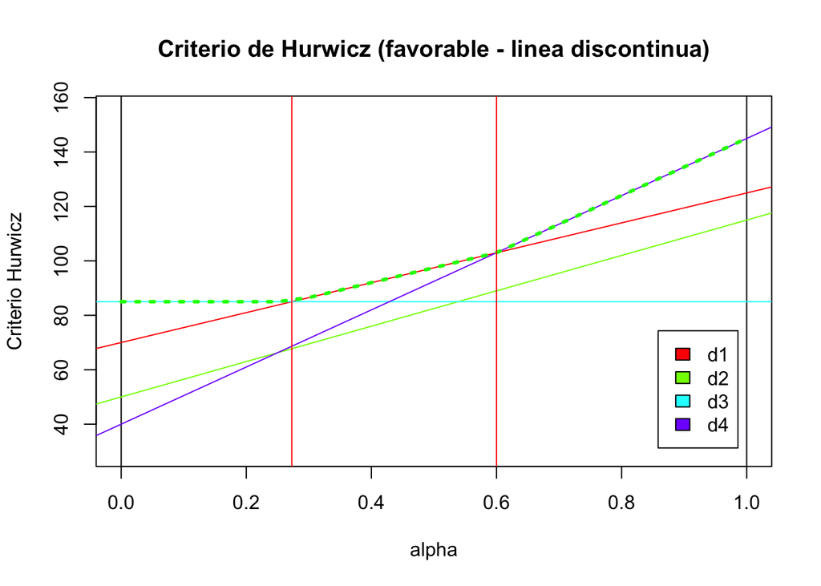

```
$AltOptimas
[1] 3 1 4

$PuntosDeCorte
[1] 0.273 0.600

$IntervalosAlfa
           Intervalo         Alternativa
Soluciones "( 0 , 0.273 )"   "3"
           "( 0.273 , 0.6 )" "1"
           "( 0.6 , 1 )"     "4"
```

```r
dibuja.criterio.Hurwicz_Intervalos(dat1a, favorable = TRUE)
```

**Conclusión.** La decisión con Hurwicz depende del grado de optimismo $\alpha$:

- $0 < \alpha < 0{,}273$: es óptima $d_3$ (la decisión “segura”, con 85 en los tres estados);
- $0{,}273 < \alpha < 0{,}6$: es óptima $d_1$;
- $0{,}6 < \alpha < 1$: es óptima $d_4$ (la de mayor potencial, $d_4$ sólo sale bien si la demanda es alta).

Es decir, **cuanto más optimista es el decisor, más se acerca a $d_4$** (la alternativa con mayor potencial, pero también con el peor peor caso: 40).

## 2.4 Apartado (b): situación desfavorable

En esta situación los valores son **costes**, de modo que todos los criterios se **minimizan**. La función `criterio.Hurwicz` invierte automáticamente los pesos: en situación desfavorable calcula $H_i(\alpha) = (1-\alpha) M_i + \alpha W_i$ y busca el **mínimo**.

### 2.4.1 1. Criterio de Wald (minimax)

**Idea.** Se toma el **peor caso** (el coste más alto, es decir el máximo de la fila) y se elige la alternativa con el menor de esos peores casos.

$$W_i = \max_j\, x_{ij}, \qquad d^* = \arg\min_i W_i$$

**Cálculo manual.** Peor caso (coste máximo) de cada alternativa:

- $d_1$: $\max(250, 300, 340) = 340$
- $d_2$: $\max(220, 280, 400) = 400$
- $d_3$: $\max(300, 260, 310) = 310$
- $d_4$: $\max(400, 230, 290) = 400$

El menor es $310$, luego **la alternativa óptima es $d_3$**.

```r
res <- criterio.Wald(dat1b, favorable = FALSE)
res$ValorAlternativas
```

```
 d1  d2  d3  d4
340 400 310 400
```

```r
res$AlternativaOptima
```

```
d3
 3
```

```r
res$ValorOptimo
```

```
[1] 310
```

### 2.4.2 2. Criterio Optimista (minimin)

**Idea.** Se toma el **mejor caso** (el coste más bajo, es decir el mínimo de la fila) y se elige la alternativa con el menor de esos mejores casos.

$$M_i = \min_j\, x_{ij}, \qquad d^* = \arg\min_i M_i$$

**Cálculo manual.** Mejor caso (coste mínimo) de cada alternativa:

- $d_1$: $\min(250, 300, 340) = 250$
- $d_2$: $\min(220, 280, 400) = 220$
- $d_3$: $\min(300, 260, 310) = 260$
- $d_4$: $\min(400, 230, 290) = 230$

El menor es $220$, luego **la alternativa óptima es $d_2$**.

```r
res <- criterio.Optimista(dat1b, favorable = FALSE)
res$ValorAlternativas
```

```
 d1  d2  d3  d4
250 220 260 230
```

```r
res$AlternativaOptima
```

```
d2
 2
```

```r
res$ValorOptimo
```

```
[1] 220
```

### 2.4.3 3. Criterio de Hurwicz ($\alpha = 0{,}3$)

**Cálculo manual** con $\alpha = 0{,}3$:

- $d_1$: $0{,}7 \cdot 340 + 0{,}3 \cdot 250 = 238 + 75 = 313$
- $d_2$: $0{,}7 \cdot 400 + 0{,}3 \cdot 220 = 280 + 66 = 346$
- $d_3$: $0{,}7 \cdot 310 + 0{,}3 \cdot 260 = 217 + 78 = 295$
- $d_4$: $0{,}7 \cdot 400 + 0{,}3 \cdot 230 = 280 + 69 = 349$

El menor valor es $295$, luego **la alternativa óptima es $d_3$**.

```r
res <- criterio.Hurwicz(dat1b, alfa = 0.3, favorable = FALSE)
res$ValorAlternativas
```

```
 d1  d2  d3  d4
313 346 295 349
```

```r
res$AlternativaOptima
```

```
d3
 3
```

```r
res$ValorOptimo
```

```
[1] 295
```

### 2.4.4 4. Criterio de Savage (minimax del regret)

**Idea.** En costes, el regret es $r_{ij} = x_{ij} - \min_i x_{ij}$ (cuánto se *“pierde”* frente a la alternativa más barata de cada estado). Luego se aplica minimax a esa matriz.

**Cálculo manual.** Mejor (menor) coste en cada estado:

- $e_1$: $\min(250, 220, 300, 400) = 220$ ($d_2$)
- $e_2$: $\min(300, 280, 260, 230) = 230$ ($d_4$)
- $e_3$: $\min(340, 400, 310, 290) = 290$ ($d_4$)

Matriz de regret:

|  | $e_1$ | $e_2$ | $e_3$ | Máx. regret |
| --- | --- | --- | --- | --- |
| $d_1$ | $250-220=30$ | $300-230=70$ | $340-290=50$ | **70** |
| $d_2$ | $220-220=0$ | $280-230=50$ | $400-290=110$ | **110** |
| $d_3$ | $300-220=80$ | $260-230=30$ | $310-290=20$ | **80** |
| $d_4$ | $400-220=180$ | $230-230=0$ | $290-290=0$ | **180** |

El menor de los máximos de regret es $70$, luego **la alternativa óptima es $d_1$**.

```r
res <- criterio.Savage(dat1b, favorable = FALSE)
res$Mejores
```

```
 e1 alta e2 media  e3 baja
     220      230      290
```

```r
res$Pesos
```

```
   e1 alta e2 media e3 baja
d1      30       70      50
d2       0       50     110
d3      80       30      20
d4     180        0       0
```

```r
res$ValorAlternativas
```

```
 d1  d2  d3  d4
 70 110  80 180
```

```r
res$AlternativaOptima
```

```
d1
 1
```

```r
res$ValorOptimo
```

```
[1] 70
```

### 2.4.5 5. Criterio de Laplace (equiprobabilidad)

**Idea.** Igual que en beneficios, pero se elige la **menor** media.

**Cálculo manual.** Media de cada alternativa:

- $d_1$: $(250 + 300 + 340)/3 = 890/3 \approx 296{,}67$
- $d_2$: $(220 + 280 + 400)/3 = 900/3 = 300$
- $d_3$: $(300 + 260 + 310)/3 = 870/3 = 290$
- $d_4$: $(400 + 230 + 290)/3 = 920/3 \approx 306{,}67$

La menor media es $290$, luego **la alternativa óptima es $d_3$**.

```r
res <- criterio.Laplace(dat1b, favorable = FALSE)
res$ValorAlternativas
```

```
      d1       d2       d3       d4
296.6667 300.0000 290.0000 306.6667
```

```r
res$AlternativaOptima
```

```
d3
 3
```

```r
res$ValorOptimo
```

```
[1] 290
```

### 2.4.6 6. Criterio del Punto Ideal

**Idea.** El punto ideal en costes es el **menor** valor posible en cada estado, y se elige la alternativa más cercana a él.

**Cálculo manual.** Punto ideal: $x^* = (220, 230, 290)$. Distancias:

- $d_1$: $\sqrt{30^2 + 70^2 + 50^2} = \sqrt{900+4900+2500} = \sqrt{8300} \approx 91{,}10$
- $d_2$: $\sqrt{0^2 + 50^2 + 110^2} = \sqrt{2500+12100} = \sqrt{14600} \approx 120{,}83$
- $d_3$: $\sqrt{80^2 + 30^2 + 20^2} = \sqrt{6400+900+400} = \sqrt{7700} \approx 87{,}75$
- $d_4$: $\sqrt{180^2 + 0^2 + 0^2} = 180$

La menor distancia es $87{,}75$, luego **la alternativa óptima es $d_3$**.

```r
res <- criterio.PuntoIdeal(dat1b, favorable = FALSE)
res$Mejores
```

```
 e1 alta e2 media  e3 baja
     220      230      290
```

```r
res$ValorAlternativas
```

```
       d1        d2        d3        d4
 91.10434 120.83046  87.74964 180.00000
```

```r
res$AlternativaOptima
```

```
d3
 3
```

```r
res$ValorOptimo
```

```
[1] 87.74964
```

### 2.4.7 7. Votación de los criterios (apartado b)

```r
cri <- list(Wald      = criterio.Wald(dat1b, FALSE)$AlternativaOptima,
            Optimista = criterio.Optimista(dat1b, FALSE)$AlternativaOptima,
            Hurwicz   = criterio.Hurwicz(dat1b, 0.3, FALSE)$AlternativaOptima,
            Savage    = criterio.Savage(dat1b, FALSE)$AlternativaOptima,
            Laplace   = criterio.Laplace(dat1b, FALSE)$AlternativaOptima,
            PuntoIdeal= criterio.PuntoIdeal(dat1b, FALSE)$AlternativaOptima)
data.frame(Criterio = names(cri), Alternativa = as.character(cri))
```

| Criterio | Alternativa |
| --- | --- |
| Wald | c(d3 = 3) |
| Optimista | c(d2 = 2) |
| Hurwicz | c(d3 = 3) |
| Savage | c(d1 = 1) |
| Laplace | c(d3 = 3) |
| PuntoIdeal | c(d3 = 3) |

| Criterio | Alternativa óptima |
| --- | --- |
| Wald | $d_3$ |
| Optimista | $d_2$ |
| Hurwicz ($\alpha=0{,}3$) | $d_3$ |
| Savage | $d_1$ |
| Laplace | $d_3$ |
| Punto Ideal | $d_3$ |

**Conclusión del apartado (b).** La alternativa $d_3$ es óptima con **cuatro** de los seis criterios (Wald, Hurwicz, Laplace y Punto Ideal) y es la más veces óptima. Savage se decanta por $d_1$ y el optimista por $d_2$. Por tanto, si lo que se busca es minimizar el coste con rasgo de prudencia, la delegación debería abrirse en la ciudad **$d_3$**.

### 2.4.8 8. Hurwicz en todo el rango $\alpha \in (0,1)$

- $d_1$: $H_1(\alpha) = 340 - 90\alpha$
- $d_2$: $H_2(\alpha) = 400 - 180\alpha$
- $d_3$: $H_3(\alpha) = 310 - 50\alpha$
- $d_4$: $H_4(\alpha) = 400 - 170\alpha$

Corte relevante: $d_3$ frente a $d_2$: $310 - 50\alpha = 400 - 180\alpha \Rightarrow 130\alpha = 90 \Rightarrow \alpha \approx 0{,}692$.

```r
res1b <- dibuja.criterio.Hurwicz_Intervalos(dat1b, favorable = FALSE, mostrarGrafico = FALSE)
res1b$IntervalosAlfa
```

```
     Intervalo       Alternativa
[1,] "( 0 , 0.692 )" "3"
[2,] "( 0.692 , 1 )" "2"
```

```r
res1b$PuntosDeCorte
```

```
[1] 0.692
```

```r
res1b$AltOptimas
```

```
[1] 3 2
```

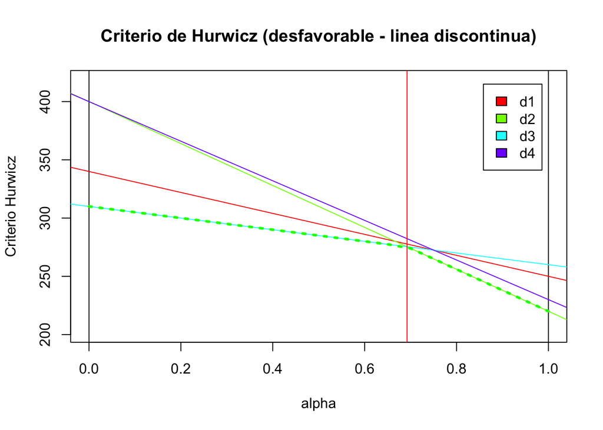

```
$AltOptimas
[1] 3 2

$PuntosDeCorte
[1] 0.692

$IntervalosAlfa
     Intervalo       Alternativa
[1,] "( 0 , 0.692 )" "3"
[2,] "( 0.692 , 1 )" "2"
```

```r
dibuja.criterio.Hurwicz_Intervalos(dat1b, favorable = FALSE)
```

**Conclusión.** Con $\alpha < 0{,}692$ (decisor poco optimista) la alternativa óptima es $d_3$; con $\alpha > 0{,}692$ (decisor muy optimista, que da mucho peso a que la demanda sea alta) la alternativa óptima pasa a ser $d_2$.

## 2.5 Respuestas verdaderas (Problema 1)

| Nº | Afirmación | Respuesta |
| --- | --- | --- |
| 1 | En el apartado (a), Wald determina como óptima $d_3$ | **VERDADERO** |
| 2 | En el apartado (a), Laplace determina como óptima $d_4$ | **FALSO** (la óptima es $d_1$, con media $\approx 96{,}67$; $d_4$ tiene la menor media, $\approx 81{,}67$) |
| 3 | En el apartado (b), Savage determina como óptima $d_1$ | **VERDADERO** |
| 4 | En el apartado (b), $d_2$ es óptima con Hurwicz para todo $\alpha \in (0,1]$ | **FALSO** ($d_2$ sólo es óptima cuando $\alpha > 0{,}692$; para $\alpha < 0{,}692$ lo es $d_3$) |
| 5 | En el apartado (b), $d_3$ es la óptima con más criterios (4 de 6) | **VERDADERO** |

# 3 Problema 2: gestión de la flota de reparto

## 3.1 Enunciado

Una **empresa española de distribución de alimentación congelada** debe decidir **cómo gestionar su flota de reparto** en el área metropolitana en la que opera:

- $d_1$: **flota propia** (camionetas frigoríficas de la empresa y conductores de plantilla);
- $d_2$: **renting** (camionetas en régimen de alquiler a largo plazo con un conductor de seguridad externo);
- $d_3$: **subcontratación** del reparto a empresas de transporte.

Los tres **estados de la naturaleza** son los escenarios de **demanda**: $e_1$ (baja), $e_2$ (media) y $e_3$ (alta). El **coste anual total** (€) de cada alternativa en cada escenario es:

| Alternativa | $e_1$ (demanda baja) | $e_2$ (demanda media) | $e_3$ (demanda alta) |
| --- | --- | --- | --- |
| $d_1$ Flota propia | 320 000 | 380 000 | 450 000 |
| $d_2$ Renting | 300 000 | 330 000 | 420 000 |
| $d_3$ Subcontratación | 250 000 | 400 000 | 600 000 |

## 3.2 Resolución con `criterio.Todos`

Esta vez se resuelve **toda la tabla de una vez** con la función `criterio.Todos`, que aplica los seis criterios y devuelve una única tabla con la decisión, el valor que cada criterio asigna a cada alternativa y la alternativa óptima de cada criterio, además del recuento de “veces óptima”.

```r
dat2 <- crea.tablaX(c(320000, 380000, 450000,
                      300000, 330000, 420000,
                      250000, 400000, 600000),
                    numalternativas = 3,
                    numestados = 3,
                    nb_alternativas = c("Flota propia", "Renting", "Subcontratacion"),
                    nb_estados = c("Demanda baja", "Demanda media", "Demanda alta"))
dat2
```

```
                Demanda baja Demanda media Demanda alta
Flota propia          320000        380000       450000
Renting               300000        330000       420000
Subcontratacion       250000        400000       600000
```

```r
res2 <- criterio.Todos(dat2, alfa = 0.5, favorable = FALSE)
res2
```

|  | Demanda baja | Demanda media | Demanda alta | Wald | Optimista | Hurwicz | Savage | Laplace | Punto Ideal | Veces Optima |
| --- | --- | --- | --- | --- | --- | --- | --- | --- | --- | --- |
| Flota propia | 320000 | 380000 | 450000 | 450000 | 320000 | 385000 | 70000 | 383333 | 91104 | 0 |
| Renting | 300000 | 330000 | 420000 | 420000 | 300000 | 360000 | 50000 | 350000 | 50000 | 5 |
| Subcontratacion | 250000 | 400000 | 600000 | 600000 | 250000 | 425000 | 180000 | 416667 | 193132 | 1 |
| iAlt.Opt (Desfav.) | – | – | – | Renting | Subcontratacion | Renting | Renting | Renting | Renting | Renting |

## 3.3 Interpretación de la tabla, criterio a criterio

```r
data.frame(
  Criterio = c("Wald", "Optimista", "Hurwicz (a=0.5)", "Savage", "Laplace", "Punto Ideal"),
  Valor  = c(criterio.Wald(dat2, FALSE)$ValorOptimo,
             criterio.Optimista(dat2, FALSE)$ValorOptimo,
             criterio.Hurwicz(dat2, 0.5, FALSE)$ValorOptimo,
             criterio.Savage(dat2, FALSE)$ValorOptimo,
             criterio.Laplace(dat2, FALSE)$ValorOptimo,
             criterio.PuntoIdeal(dat2, FALSE)$ValorOptimo),
  Alternativa = c("Renting", "Subcontratacion", "Renting", "Renting", "Renting", "Renting"))
```

| Criterio | Valor | Alternativa |
| --- | --- | --- |
| Wald | 420000 | Renting |
| Optimista | 250000 | Subcontratacion |
| Hurwicz (a=0.5) | 360000 | Renting |
| Savage | 50000 | Renting |
| Laplace | 350000 | Renting |
| Punto Ideal | 50000 | Renting |

| Criterio | Cálculo | Alternativa óptima |
| --- | --- | --- |
| **Wald** (pesimista) | Se toma el coste máximo de cada fila y se elige el menor: $d_1=450\,000$, $d_2=420\,000$, $d_3=600\,000$ → el menor es $420\,000$ | **Renting** ($d_2$) |
| **Optimista** | Se toma el coste mínimo de cada fila y se elige el menor: $d_1=320\,000$, $d_2=300\,000$, $d_3=250\,000$ → el menor es $250\,000$ | **Subcontratación** ($d_3$) |
| **Hurwicz** ($\alpha=0{,}5$) | $H_i = 0{,}5 M_i + 0{,}5 W_i$: $d_1=385\,000$, $d_2=360\,000$, $d_3=425\,000$ → el menor es $360\,000$ | **Renting** ($d_2$) |
| **Savage** (regret) | Regret $r_{ij}=x_{ij}-\min_i x_{ij}$; máximos de regret: $d_1=70\,000$, $d_2=50\,000$, $d_3=180\,000$ → el menor es $50\,000$ | **Renting** ($d_2$) |
| **Laplace** | Medias: $d_1\approx383\,333$, $d_2=350\,000$, $d_3\approx416\,667$ → la menor es $350\,000$ | **Renting** ($d_2$) |
| **Punto Ideal** | Punto ideal $(250\,000,\ 330\,000,\ 420\,000)$; distancias: $d_1\approx91\,104$, $d_2=50\,000$, $d_3\approx193\,132$ → la menor es $50\,000$ | **Renting** ($d_2$) |

**Votación.** La columna *“Veces Optima”* de la tabla anterior resume el recuento:

| Alternativa | Veces óptima |
| --- | --- |
| Flota propia ($d_1$) | 0 |
| Renting ($d_2$) | **5** |
| Subcontratación ($d_3$) | 1 |

## 3.4 Interpretación económica

La tabla de costes tiene una lectura muy clara:

**Recomendación.** La dirección debería **elegir el renting ($d_2$)**: es la alternativa más barata en los escenarios de demanda **media** y **alta**, es más barata que la flota propia en **todos** los escenarios, y **ningún** criterio salvo el optimista se decanta por otra opción. Es por tanto la decisión **robusta**: sólo un decisor **extremadamente optimista** (que mire únicamente el mejor escenario) elegiría la subcontratación. La subcontratación sólo sería conveniente si la dirección tuviera **mucha confianza** en que la demanda se mantendría baja.

## 3.5 Hurwicz en todo el rango $\alpha \in (0,1)$

Las rectas de Hurwicz (situación desfavorable) son:

- $d_1$: $H_1(\alpha) = (1-\alpha)\,450\,000 + \alpha\,320\,000 = 450\,000 - 130\,000\,\alpha$
- $d_2$: $H_2(\alpha) = (1-\alpha)\,420\,000 + \alpha\,300\,000 = 420\,000 - 120\,000\,\alpha$
- $d_3$: $H_3(\alpha) = (1-\alpha)\,600\,000 + \alpha\,250\,000 = 600\,000 - 350\,000\,\alpha$

Corte entre $d_2$ y $d_3$:

$$420\,000 - 120\,000\alpha = 600\,000 - 350\,000\alpha
\;\Rightarrow\; 230\,000\alpha = 180\,000 \;\Rightarrow\; \alpha = \frac{18}{23} \approx 0{,}783$$

```r
res2dib <- dibuja.criterio.Hurwicz_Intervalos(dat2, favorable = FALSE, mostrarGrafico = FALSE)
res2dib$IntervalosAlfa
```

```
     Intervalo       Alternativa
[1,] "( 0 , 0.783 )" "2"
[2,] "( 0.783 , 1 )" "3"
```

```r
res2dib$PuntosDeCorte
```

```
[1] 0.783
```

```r
res2dib$AltOptimas
```

```
[1] 2 3
```

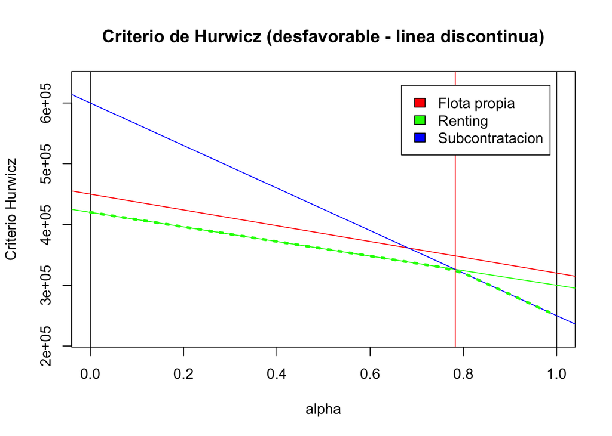

```
$AltOptimas
[1] 2 3

$PuntosDeCorte
[1] 0.783

$IntervalosAlfa
     Intervalo       Alternativa
[1,] "( 0 , 0.783 )" "2"
[2,] "( 0.783 , 1 )" "3"
```

```r
dibuja.criterio.Hurwicz_Intervalos(dat2, favorable = FALSE)
```

**Conclusión.**

- $0 < \alpha < 0{,}783$: la alternativa óptima es el **renting** ($d_2$).
- $0{,}783 < \alpha < 1$: la alternativa óptima pasa a ser la **subcontratación** ($d_3$).

El punto de corte $\alpha \approx 0{,}783$ significa que la decisión sólo cambiaría si el decisor fuese **extremadamente optimista** (daría un peso del 78 % al mejor escenario frente al peor). La **flota propia** ($d_1$) no es óptima **para ningún valor** de $\alpha$, lo que confirma que es una alternativa **dominada**.

## 3.6 Respuestas verdaderas (Problema 2)

| Nº | Afirmación | Respuesta |
| --- | --- | --- |
| 1 | El criterio de Wald recomienda el renting ($d_2$) | **VERDADERO** (Wald da $420\,000$ € frente a $450\,000$ € de $d_1$ y $600\,000$ € de $d_3$) |
| 2 | El criterio de Laplace recomienda la flota propia ($d_1$) | **FALSO** (Laplace recomienda el renting, con media $350\,000$ €; $d_1$ tiene la media más alta, $\approx 383\,333$ €) |
| 3 | El criterio Optimista recomienda la subcontratación ($d_3$) | **VERDADERO** (con demanda baja la subcontratación cuesta $250\,000$ €, el mínimo de la tabla) |
| 4 | Con Hurwicz, la subcontratación es óptima para todo $\alpha \in (0,1]$ | **FALSO** (sólo lo es cuando $\alpha > 0{,}783$; para $\alpha < 0{,}783$ lo es el renting) |
| 5 | La flota propia ($d_1$) no es la alternativa óptima con ningún criterio | **VERDADERO** (0 veces óptima; está dominada por el renting en los tres estados) |

# 4 Resumen final

| Problema | Criterio | Alternativa óptima |
| --- | --- | --- |
| 1(a) — beneficios | Wald | $d_3$ |
| 1(a) — beneficios | Optimista | $d_4$ |
| 1(a) — beneficios | Hurwicz ($\alpha=0{,}3$) | $d_1$ |
| 1(a) — beneficios | Savage | $d_1$ |
| 1(a) — beneficios | Laplace | $d_1$ |
| 1(a) — beneficios | Punto Ideal | $d_1$ |
| 1(a) — **más veces óptima** | — | **$d_1$ (4 de 6)** |
| 1(b) — costes | Wald | $d_3$ |
| 1(b) — costes | Optimista | $d_2$ |
| 1(b) — costes | Hurwicz ($\alpha=0{,}3$) | $d_3$ |
| 1(b) — costes | Savage | $d_1$ |
| 1(b) — costes | Laplace | $d_3$ |
| 1(b) — costes | Punto Ideal | $d_3$ |
| 1(b) — **más veces óptima** | — | **$d_3$ (4 de 6)** |
| 2 — costes (real) | Wald | Renting ($d_2$) |
| 2 — costes (real) | Optimista | Subcontratación ($d_3$) |
| 2 — costes (real) | Hurwicz ($\alpha=0{,}5$) | Renting ($d_2$) |
| 2 — costes (real) | Savage | Renting ($d_2$) |
| 2 — costes (real) | Laplace | Renting ($d_2$) |
| 2 — costes (real) | Punto Ideal | Renting ($d_2$) |
| 2 — costes (real) | **más veces óptima** | **Renting ($d_2$), 5 de 6** |

**Puntos de corte del criterio de Hurwicz**

| Problema | Puntos de corte | Alternativa óptima en cada tramo |
| --- | --- | --- |
| 1(a) | $\alpha \approx 0{,}273$ y $\alpha = 0{,}6$ | $d_3$ $(0,\,0{,}273)$; $d_1$ $(0{,}273,\,0{,}6)$; $d_4$ $(0{,}6,\,1)$ |
| 1(b) | $\alpha \approx 0{,}692$ | $d_3$ $(0,\,0{,}692)$; $d_2$ $(0{,}692,\,1)$ |
| 2 | $\alpha \approx 0{,}783$ | Renting $(0,\,0{,}783)$; Subcontratación $(0{,}783,\,1)$ |